# Segmentación de prospectos y validación de clusters

Author

BI Evolution

## 1. Preparación del entorno

## 2. Carga del dataset de prospectos

Se asume que el archivo `prospectos.csv` está en el mismo directorio que este Quarto.

```
Rows: 1,000
Columns: 14
$ id_prospecto          <dbl> 1, 2, 3, 4, 5, 6, 7, 8, 9, 10, 11, 12, 13, 14, 1…
$ edad                  <dbl> 34, 39, 42, 46, 44, 39, 47, 23, 44, 24, 39, 26, …
$ genero                <chr> "F", "M", "F", "F", "M", "M", "F", "F", "M", "M"…
$ ingresos_mensuales    <dbl> 2841, 3291, 2180, 4521, 5796, 7483, 7732, 2250, …
$ canal_origen          <chr> "Instagram", "Instagram", "Instagram", "Google A…
$ interes_producto      <chr> "Servicio C", "Servicio A", "Servicio C", "Servi…
$ nivel_interes         <dbl> 3, 4, 2, 3, 4, 4, 4, 3, 4, 1, 4, 3, 1, 2, 4, 5, …
$ tiempo_respuesta_min  <dbl> 60, 11, 66, 32, 10, 9, 12, 4, 39, 73, 11, 10, 67…
$ interacciones_previas <dbl> 0, 1, 0, 4, 5, 6, 6, 3, 5, 0, 5, 3, 0, 0, 5, 6, …
$ visitas_web           <dbl> 3, 7, 2, 5, 9, 8, 7, 8, 6, 2, 6, 11, 2, 3, 9, 8,…
$ open_rate             <dbl> 0.5805742, 0.5137994, 0.2301306, 0.5609765, 0.86…
$ email_score           <dbl> 76, 79, 46, 72, 91, 90, 92, 89, 76, 43, 93, 82, …
$ tiempo_decision_dias  <dbl> 13, 1, 28, 32, 3, 1, 2, 5, 34, 37, 3, 2, 38, 13,…
$ estado_embudo         <chr> "Interesado", "Interesado", "Contacto Nuevo", "I…
```

## 3. Selección de variables numéricas y estandarización

Seleccionamos solo variables numéricas para el clustering. (Se pueden ajustar según tu criterio de negocio.)

```
      edad          ingresos_mensuales nivel_interes     tiempo_respuesta_min
 Min.   :-1.99335   Min.   :-1.5175    Min.   :-1.9980   Min.   :-1.2048
 1st Qu.:-0.84358   1st Qu.:-0.7894    1st Qu.:-1.0836   1st Qu.:-0.9241
 Median : 0.07623   Median :-0.2775    Median :-0.1692   Median :-0.1220
 Mean   : 0.00000   Mean   : 0.0000    Mean   : 0.0000   Mean   : 0.0000
 3rd Qu.: 0.76609   3rd Qu.: 0.7724    3rd Qu.: 0.7452   3rd Qu.: 0.8406
 Max.   : 1.91586   Max.   : 2.4687    Max.   : 1.6596   Max.   : 2.2443
 interacciones_previas  visitas_web        open_rate         email_score
 Min.   :-1.2563       Min.   :-1.8728   Min.   :-2.14224   Min.   :-2.42507
 1st Qu.:-0.7173       1st Qu.:-0.6609   1st Qu.:-0.65456   1st Qu.:-0.80091
 Median :-0.1784       Median : 0.1470   Median :-0.04452   Median : 0.01117
 Mean   : 0.0000       Mean   : 0.0000   Mean   : 0.00000   Mean   : 0.00000
 3rd Qu.: 0.8995       3rd Qu.: 0.5510   3rd Qu.: 0.82519   3rd Qu.: 0.95859
 Max.   : 1.9774       Max.   : 2.1669   Max.   : 1.71532   Max.   : 1.56765
 tiempo_decision_dias
 Min.   :-1.17535
 1st Qu.:-0.99596
 Median :-0.09902
 Mean   : 0.00000
 3rd Qu.: 0.70822
 Max.   : 2.23301
```

## 4. Validación de estabilidad con `clValid` (APN, AD, ADM, FOM)

En esta sección vamos a calcular medidas de **estabilidad del clustering**, evaluando qué tanto cambian los resultados cuando se elimina una variable del conjunto de datos.

Las métricas consideradas son:

- **APN (Average Proportion of Non-overlap)**  
  Mide qué proporción de observaciones cambian de cluster cuando se elimina una variable.  
  **APN bajo → clustering estable**.
- **AD (Average Distance)**  
  Mide cuánto cambian las distancias internas dentro de los clusters al remover una variable.  
  **AD bajo → clusters robustos y compactos**.
- **ADM (Average Distance between Means)**  
  Mide cuánto se mueven los centros de los clusters al quitar una variable.  
  **ADM bajo → clusters con estructura estable**.
- **FOM (Figure of Merit)**  
  Mide la variabilidad interna de la variable eliminada usando el clustering basado en las demás.  
  **FOM bajo → clusters más coherentes**.

Se evaluarán los métodos:

- `kmeans`
- `clara`
- `hierarchical`
- `fanny`

para números de clusters `k` entre 2 y 8.

```
Clustering Methods:
 kmeans clara hierarchical fanny

Cluster sizes:
 2 3 4 5 6 7 8

Validation Measures:
                       2      3      4      5      6      7      8

kmeans       APN  0.0338 0.1703 0.1743 0.0081 0.0592 0.0745 0.0522
             AD   2.9756 2.7483 2.4941 1.9755 1.9489 1.8990 1.8292
             ADM  0.1622 0.7792 0.7286 0.0253 0.1837 0.1836 0.1285
             FOM  0.7454 0.7153 0.6504 0.4739 0.4737 0.4724 0.4702
clara        APN  0.1198 0.1829 0.1270 0.0422 0.1327 0.1941 0.2804
             AD   3.1855 2.7462 2.4336 2.0206 2.0149 1.9837 1.9858
             ADM  0.4913 0.7639 0.4526 0.1298 0.2807 0.3733 0.4757
             FOM  0.8252 0.6988 0.6459 0.5111 0.5082 0.4944 0.4929
hierarchical APN  0.3417 0.1937 0.1609 0.0086 0.0599 0.1022 0.1217
             AD   3.6560 2.8129 2.4821 1.9764 1.9584 1.9188 1.8736
             ADM  1.7619 0.8332 0.6988 0.0250 0.1861 0.2269 0.2484
             FOM  0.8322 0.7141 0.6468 0.4698 0.4700 0.4699 0.4699
fanny        APN  0.0662 0.1278     NA     NA     NA     NA     NA
             AD   3.0273 2.7577     NA     NA     NA     NA     NA
             ADM  0.2619 0.3447     NA     NA     NA     NA     NA
             FOM  0.7740 0.7119     NA     NA     NA     NA     NA

Optimal Scores:

    Score  Method       Clusters
APN 0.0081 kmeans       5
AD  1.8292 kmeans       8
ADM 0.0250 hierarchical 5
FOM 0.4698 hierarchical 5
```

### 4.1. Tabla de métricas de estabilidad (APN, AD, ADM, FOM)

A continuación extraemos las métricas en un `data.frame` para analizarlas y ordenarlas por los valores más bajos (más estables).

```
   Measure Clusters       Method     Score
1      FOM        5 hierarchical 0.4698407
2      FOM        7 hierarchical 0.4698991
3      FOM        8 hierarchical 0.4699446
4      FOM        6 hierarchical 0.4699546
5      FOM        8       kmeans 0.4702087
6      FOM        7       kmeans 0.4723978
7      FOM        6       kmeans 0.4736716
8      FOM        5       kmeans 0.4738955
9      FOM        8        clara 0.4928610
10     FOM        7        clara 0.4944480
```

## 📊 Sección 5 – Solo *internal validity* (silhouette, Dunn, etc.)

Aquí analizas **qué tan buenos** son los clusters desde el punto de vista interno (sin quitar variables), usando índices clásicos de calidad de clustering.

## 5. Validación interna con `clValid` (índices de calidad)

En esta sección evaluamos la **calidad interna** de los clusters usando índices clásicos:

- **Silhouette width - Tiene más peso dentro de las métricas**  
  Mide qué tan similar es cada observación a su propio cluster en comparación con otros clusters.  
  Toma valores entre -1 y 1.  
  **Valores cercanos a 1 → clusters bien separados y compactos.**
- **Índice de Dunn**  
  Relaciona la distancia mínima entre clusters con el diámetro máximo dentro de los clusters.Su valor es mayor a 0 **Dunn alto → clusters bien separados y poco dispersos.**
- **Connectivity**  
  Mide la medida en que observaciones cercanas en el espacio de características terminan en clusters distintos. Su valor es mayor a 0 **Connectivity baja → clustering más “natural” según la proximidad de los puntos.**

(Otros índices pueden aparecer en la salida de `clValid`, pero aquí nos centraremos en estos como referencia principal.)

```
Clustering Methods:
 kmeans clara hierarchical fanny

Cluster sizes:
 2 3 4 5 6 7 8

Validation Measures:
                                  2        3        4        5        6        7        8

kmeans       Connectivity   37.4183  46.0365  33.6000  11.7492  66.5321  89.9091 171.3798
             Dunn            0.1207   0.0948   0.1453   0.1814   0.1822   0.1849   0.1455
             Silhouette      0.3783   0.3365   0.3290   0.4053   0.3657   0.3413   0.3090
clara        Connectivity  151.9405 100.0754 179.5417  50.1496 131.2024 218.9583 334.1151
             Dunn            0.0735   0.0998   0.1125   0.1145   0.1595   0.1290   0.0931
             Silhouette      0.3427   0.3275   0.3292   0.4003   0.3516   0.3272   0.1888
hierarchical Connectivity    0.4929   2.6512   4.1151   8.9516  58.2734  78.7917 147.0734
             Dunn            0.1665   0.1434   0.1446   0.2101   0.2101   0.2132   0.2035
             Silhouette      0.3352   0.3187   0.3302   0.4052   0.3622   0.3362   0.2974
fanny        Connectivity  119.0103 256.9798       NA       NA       NA       NA       NA
             Dunn            0.1034   0.0883       NA       NA       NA       NA       NA
             Silhouette      0.3668   0.2431       NA       NA       NA       NA       NA

Optimal Scores:

             Score  Method       Clusters
Connectivity 0.4929 hierarchical 2
Dunn         0.2132 hierarchical 7
Silhouette   0.4053 kmeans       5
```

### 5.1. Selección del mejor método y k según índices internos

`clValid` también resume cuál combinación de método y número de clusters optimiza cada índice.

```
Clustering Methods:
 kmeans clara hierarchical fanny

Cluster sizes:
 2 3 4 5 6 7 8

Validation Measures:
                                  2        3        4        5        6        7        8

kmeans       Connectivity   37.4183  46.0365  33.6000  11.7492  66.5321  89.9091 171.3798
             Dunn            0.1207   0.0948   0.1453   0.1814   0.1822   0.1849   0.1455
             Silhouette      0.3783   0.3365   0.3290   0.4053   0.3657   0.3413   0.3090
clara        Connectivity  151.9405 100.0754 179.5417  50.1496 131.2024 218.9583 334.1151
             Dunn            0.0735   0.0998   0.1125   0.1145   0.1595   0.1290   0.0931
             Silhouette      0.3427   0.3275   0.3292   0.4003   0.3516   0.3272   0.1888
hierarchical Connectivity    0.4929   2.6512   4.1151   8.9516  58.2734  78.7917 147.0734
             Dunn            0.1665   0.1434   0.1446   0.2101   0.2101   0.2132   0.2035
             Silhouette      0.3352   0.3187   0.3302   0.4052   0.3622   0.3362   0.2974
fanny        Connectivity  119.0103 256.9798       NA       NA       NA       NA       NA
             Dunn            0.1034   0.0883       NA       NA       NA       NA       NA
             Silhouette      0.3668   0.2431       NA       NA       NA       NA       NA

Optimal Scores:

             Score  Method       Clusters
Connectivity 0.4929 hierarchical 2
Dunn         0.2132 hierarchical 7
Silhouette   0.4053 kmeans       5
```

Y puedes cruzar con estabilidad:

```
Clustering Methods:
 kmeans clara hierarchical fanny

Cluster sizes:
 2 3 4 5 6 7 8

Validation Measures:
                       2      3      4      5      6      7      8

kmeans       APN  0.0338 0.1703 0.1743 0.0081 0.0592 0.0745 0.0522
             AD   2.9756 2.7483 2.4941 1.9755 1.9489 1.8990 1.8292
             ADM  0.1622 0.7792 0.7286 0.0253 0.1837 0.1836 0.1285
             FOM  0.7454 0.7153 0.6504 0.4739 0.4737 0.4724 0.4702
clara        APN  0.1198 0.1829 0.1270 0.0422 0.1327 0.1941 0.2804
             AD   3.1855 2.7462 2.4336 2.0206 2.0149 1.9837 1.9858
             ADM  0.4913 0.7639 0.4526 0.1298 0.2807 0.3733 0.4757
             FOM  0.8252 0.6988 0.6459 0.5111 0.5082 0.4944 0.4929
hierarchical APN  0.3417 0.1937 0.1609 0.0086 0.0599 0.1022 0.1217
             AD   3.6560 2.8129 2.4821 1.9764 1.9584 1.9188 1.8736
             ADM  1.7619 0.8332 0.6988 0.0250 0.1861 0.2269 0.2484
             FOM  0.8322 0.7141 0.6468 0.4698 0.4700 0.4699 0.4699
fanny        APN  0.0662 0.1278     NA     NA     NA     NA     NA
             AD   3.0273 2.7577     NA     NA     NA     NA     NA
             ADM  0.2619 0.3447     NA     NA     NA     NA     NA
             FOM  0.7740 0.7119     NA     NA     NA     NA     NA

Optimal Scores:

    Score  Method       Clusters
APN 0.0081 kmeans       5
AD  1.8292 kmeans       8
ADM 0.0250 hierarchical 5
FOM 0.4698 hierarchical 5
```

> **Nota:** Estas salidas te dan una idea de qué método y k suelen ser mejores.

## 6. k óptimo para k-means: elbow, silhouette y gap statistic

Aquí enfocamos solo en k-means para ilustrar los métodos clásicos de selección de k.

### 6.1. Método del codo (WSS)

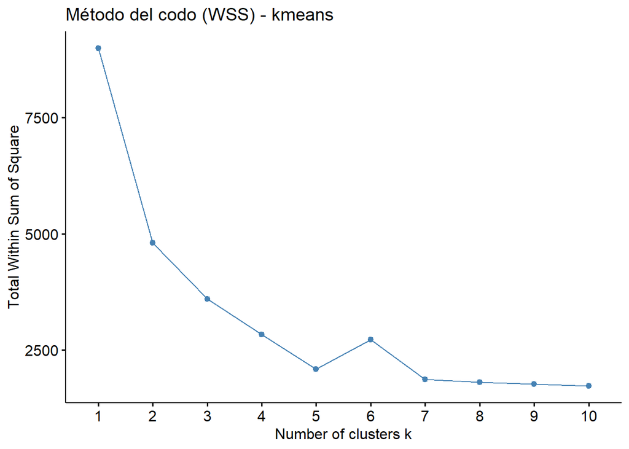

### 6.2. Silhouette medio

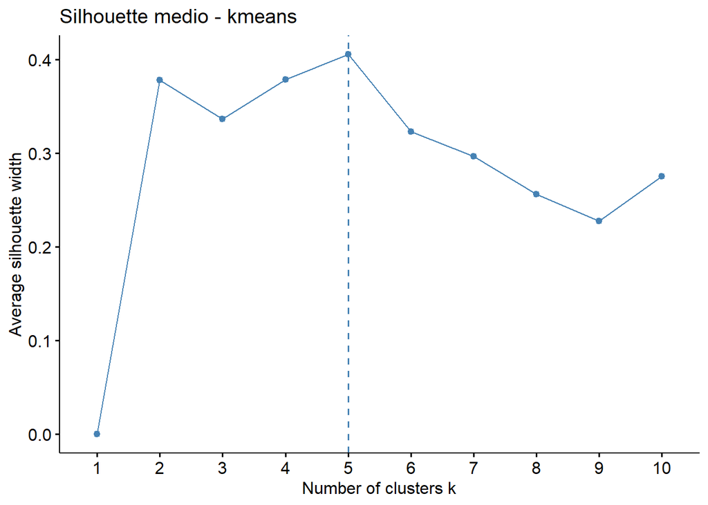

### 6.3. Gap statistic

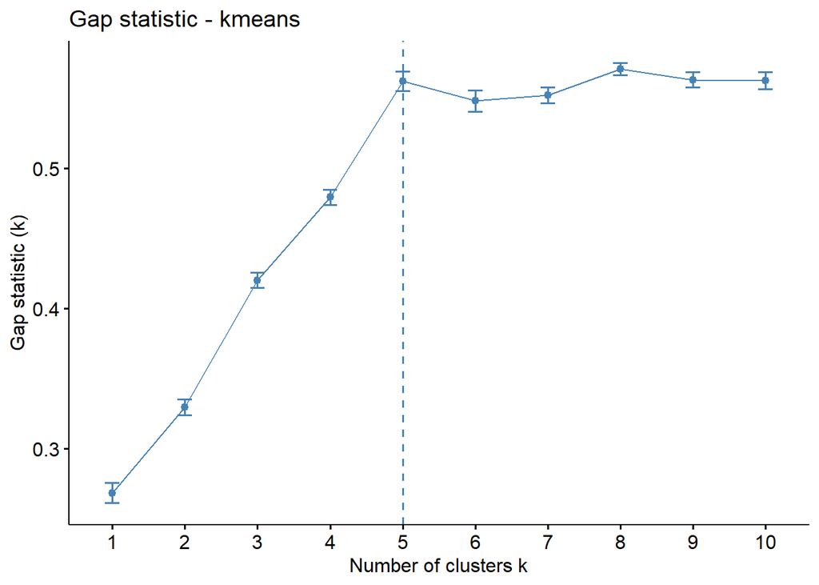

## 7. DBSCAN (extra, sin APN/AD/ADM/FOM)

DBSCAN no se presta igual a APN/AD/ADM/FOM porque no usa un k fijo. Igual podemos explorarlo con silhouette y visualización.

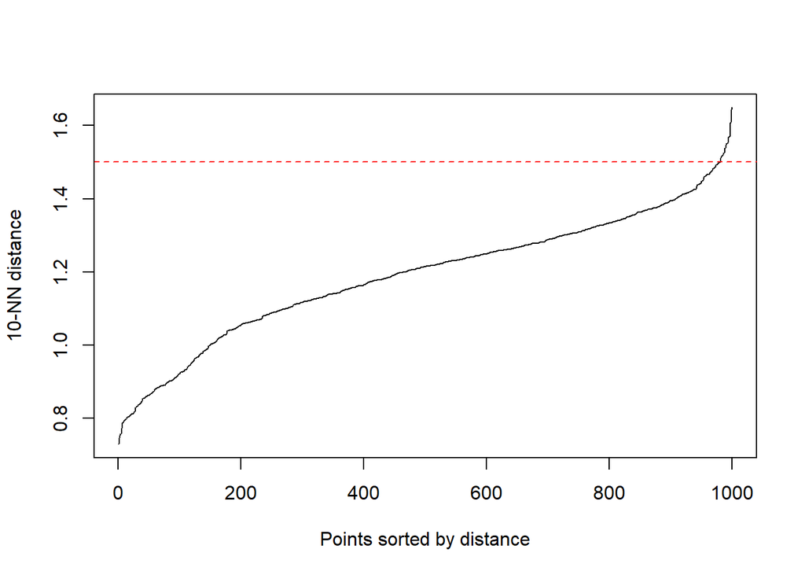

```
   1
1000
```

```
DBSCAN no generó suficientes clusters válidos para calcular silhouette.
```

## 8. Entrenamiento final con el método y k elegidos

En esta sección tú eliges, a partir de las métricas anteriores, el **método + k** que te parezca mejor.

Para el ejemplo, supongamos que elegimos:

> Cambia estos valores según lo que veas en las métricas.

### 8.1. Ajuste según el método elegido

```
  1   2   3   4   5
208 135 226 278 153
```

### 8.2. Resumen de perfiles por cluster

```
# A tibble: 5 × 9
  cluster_final     n edad_media ingresos_medios nivel_interes_med
  <fct>         <int>      <dbl>           <dbl>             <dbl>
1 1               208       41.1           4479.              3.51
2 2               135       36.3           2103.              1.54
3 3               226       44.4           6197.              4.52
4 4               278       31.8           2544.              2.47
5 5               153       32.6           3043.              3.51
# ℹ 4 more variables: visitas_web_med <dbl>, open_rate_med <dbl>,
#   email_score_med <dbl>, tiempo_dec_med <dbl>
```

## 9. Visualización final con PCA

Hacemos un PCA sobre las variables escaladas y coloreamos por `cluster_final`.

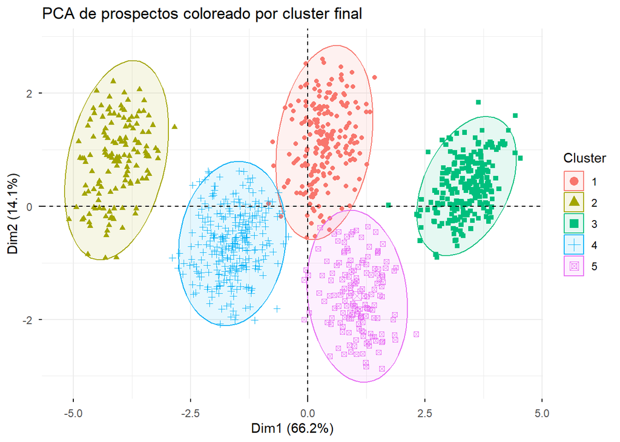